# Part I, Homography

Homography, or perspective rectification, is the process of adjusting a 2D image from one perspective to another (e.g. taking an image tha appears at a slant with vanishing perspectiv points and transfroming it to an image that appears head on). For examples of this in action, see:

- learnopencv.com/homography-examples-using-opencv-python-c/
- inst.eecs.berkeley.edu/~cs194-26/fa17/upload/files/proj6A/cs194-26-adp/
- people.scs.carleton.ca/~roth/comp4900d-12/notes/homography.pdf (pages 17-22)

Python has built in code that will find the transformation matrix for this linear operator.

For this project you will take or find an image taken from a slanted angle, and use the tools below to straighten it out so it looks like it’s taken head on.

## Instructions

1. Upload you image running the code below.
2. Read ove the code at the end of this file for an example of how you are going to transfrom your image.

```python
from PIL import Image
import numpy as np
import matplotlib.pyplot as plt
from skimage import transform
import math
import cv2


from google.colab import files
uploaded = files.upload()
```

Upload widget is only available when the cell has been executed in the current browser session. Please rerun this cell to enable.

```
Saving MATH352.jpg to MATH352.jpg
```

3. Write code in the cell below to add colored dots to your image that would be the vertices of a rectangle if your image were viewed head on (they should instead look like vertices of a quadrilateral on your slanted image). Finding the right placement of these vertices requires some trial and error, but is critical in calculating the correct homography matrix.

[figure not shown]

[figure not shown]

[figure not shown]

[figure not shown]

```python
# Load the slanted image
math_image = Image.open("MATH352.jpg")

# Resize the image to 400x300 pixels
math_image = math_image.resize((400, 300))

display(math_image)

# Convert the image to black and white
math_image = math_image.convert('L')


# Display the processed image
display(math_image)


tform = transform.SimilarityTransform(scale=1, rotation=math.pi/8*(-1), translation=(0,50))
slanted_math_image = transform.warp(np.array(math_image), tform)  # Using the generated matrix to transform the image
plt.imshow(slanted_math_image, cmap=plt.cm.gray)  # Displaying the resulting image
plt.show()


plt.plot(60, 90, marker='o', color="blue")
plt.plot(220, 60, marker='o', color="red")
plt.plot(220, 250, marker='o', color="yellow")
plt.plot(58, 220, marker='o', color="green")
plt.imshow(math_image, cmap="gray")
plt.show()
```

4. Write code in the cell below that uses the points you found in problem 3 to determine the homography matrix, and applies this matrix to transform the image. See the code at the bottom of this file for an example.

```
Homography Matrix = [[ 6.31828438e-02  4.69280929e-01  3.03236304e+01]
 [ 5.42320640e-01 -2.31152713e-01  7.30977109e+01]
 [ 3.67711791e-04 -1.93034062e-03  1.00000000e+00]]
```

[figure not shown]

```python
src_points = np.array([[60, 90], [220, 60], [220, 250], [58, 220]])

# Define the coordinates of the rectangle in the transformed image (head-on view)
# Adjusted to match the corners of the slanted image
dst_points = np.array([[90, 100], [75, 185], [270, 225], [230, 90]])

# Calculate the homography matrix using the points
homography_matrix, _ = cv2.findHomography(src_points, dst_points)
print(f"Homography Matrix = {homography_matrix}")

# Transform the image by the homography matrix
fixed_math_image = transform.warp(np.array(math_image), homography_matrix)

# Swap width and height of the transformed image
fixed_math_image = np.swapaxes(fixed_math_image, 0, 1)

# Display the transformed image
plt.imshow(fixed_math_image, cmap=plt.cm.gray)
plt.show()
```

# Part II, Homogenous Coordinates

Homogeneous coordinates allow us to realize translations - things like $T(\vec{v})=\vec{v}+\vec{v}_0$, which you know are not linear transformations - as linear transfromations in a higher dimension. Pretty cool, especially given how simple they are. Humans are so smart! Amazing.

## Instructions

1. Read Section [6.5 of your text](https://djvu.online/file/OpgzvCNhXbqF5) on homogenous coordinates and graphics.
2. Using homogeneous coordinates find a matrix that rotates vectors in $\mathbb{R}^2$ by 30 degrees clockwise, then scales the image such that $<x,y>$ becomes $<2x,7y>$, and then translates the image by the vector $\vec{v}=< 50, 20 >.$
3. Encode the matrix you found in problem 2 below and use it to transform your image.

[figure not shown]

```python
theta = np.radians(math.pi/6)  # Rotation angle in radians (clockwise)
rotation_matrix = np.array([[np.cos(theta), -np.sin(theta)],
                            [np.sin(theta), np.cos(theta)]])

# Define the scaling matrix to scale the image such that <x, y> becomes <2x, 7y>
scaling_matrix = np.array([[2, 0],
                            [0, 7]])

# Define the translation vector to translate the image by the vector <50, 20>
translation_vector = np.array([50, 20])

# Combine the rotation and scaling matrices
rotation_scaling_matrix = np.dot(rotation_matrix, scaling_matrix)

# Define the transformation matrix
transformation_matrix = np.eye(3)  # Identity matrix
transformation_matrix[:2, :2] = rotation_scaling_matrix
transformation_matrix[:2, 2] = translation_vector

# Apply the transformation to the image
transformed_image = transform.warp(np.array(math_image), transformation_matrix)

# Display the transformed image
plt.imshow(transformed_image, cmap=plt.cm.gray)
plt.show()
```

7. **Refelct on the assignment. Write a brief paragraph answering the following:** What did you learn? What parts did your enjoy? Wich parts challenged you the most? And advise for future renditions of the assignment?

We learned how linear algebra can be used to make homographic photos and how more general aspects of linear algebra can be applied (especially with coding). Part I's homography was enjoyable with changing the image to make it look like you were facing it head-on. It was a bit daunting at first because on paper, it sounds like an absolute nightmare to code, but working through it piece by piece made it manageable. The most challenging part was definitely Part II. Understanding how we were supposed to code the transformation was difficult and there was a lot of trial and error with getting the image to not be a stretched-out mess. Maybe a more in-depth example at the bottom might help?

# Example Code

```python
# Uploading and image
```

Upload widget is only available when the cell has been executed in the current browser session. Please rerun this cell to enable.

```
Saving hearth.jpg to hearth.jpg
```

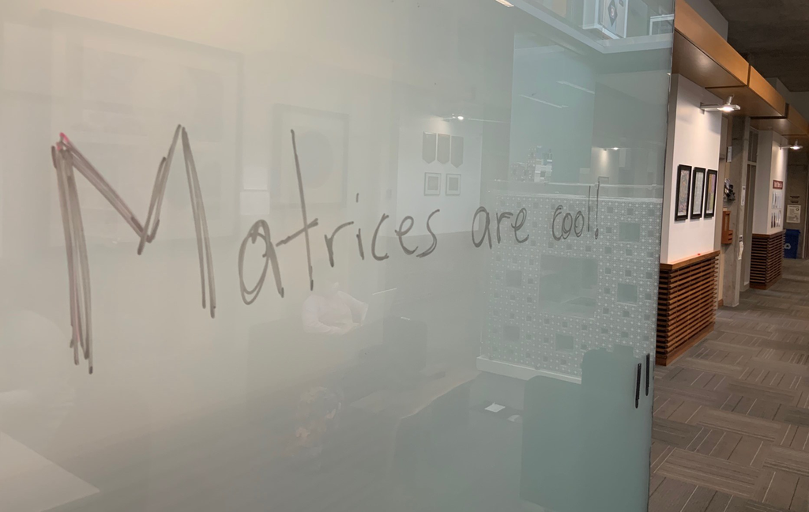

```python
# Displaying the uploaded image
hearth=Image.open("hearth.jpg")
display(hearth)
```

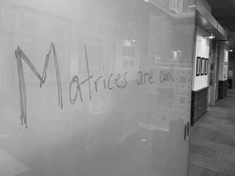

```python
# Some basic image processing commands
hearth=hearth.convert('L') #convert to black and white
hearth=hearth.resize((400,300)) #resize to 400x300 pixels
display(hearth)
```

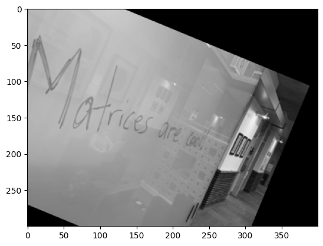

```python
# Examples from the python graphics library Image
tform = transform.SimilarityTransform(scale=1, rotation=math.pi/8*(-1), translation=(0,50))  #Generating the matrix that performs a rotation
slantedhearth = transform.warp(np.matrix(hearth), tform) #Using the generated matrix to transform the image
plt.imshow(slantedhearth, cmap=plt.cm.gray) #Displaying the resulting image
```

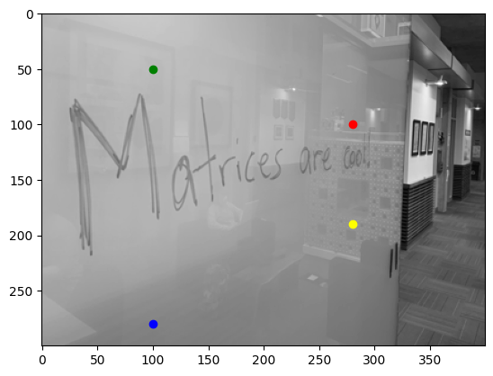

```python
#By trial and error, finding points that will define a rectangle in our head-on image.  You will need to do something similar for Part I problem 3
plt.plot(100, 280, marker='o', color="blue")
plt.plot(280, 100, marker='o', color="red")
plt.plot(280, 190, marker='o', color="yellow")
plt.plot(100, 50, marker='o', color="green")
plt.imshow(hearth,cmap="gray")
plt.show()
```

```python
#Python code for finding the homography matrix that will rectify the quadrilateral you found in problem 3 to the rectangle - this is the process you will use in Part I problem 4
scalematrix=cv2.findHomography(np.array([[100,50],[100,280],[280,50],[280,280]]),np.array([[100,50],[100,280],[280,100],[280,190]]))[0] #mapping any four points to any four points
scalematrix
```

```
array([[ 2.51818182e+01, -4.68331670e-16, -1.78181818e+03],
       [ 8.40909091e+00,  7.36363636e+00, -8.40909091e+02],
       [ 6.36363636e-02, -2.46490352e-18,  1.00000000e+00]])
```

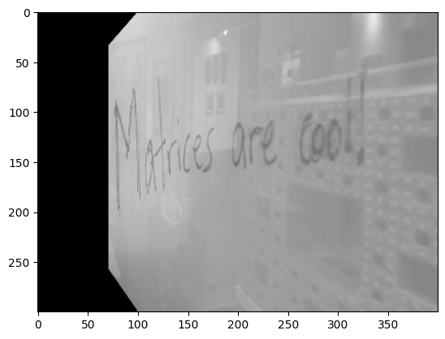

```python
#Transforming the image by the homography matrix.- This is not a very good example.  I should spend more time adjusting the vertices of the the quadrilateral on the image.
fixedhearth = transform.warp(np.array(hearth), scalematrix)
plt.imshow(fixedhearth, cmap=plt.cm.gray)
```

```python
!jupyter nbconvert --to html Image_Transformation.ipynb
```

```
[NbConvertApp] Converting notebook Image_Transformation.ipynb to html
[NbConvertApp] WARNING | Alternative text is missing on 11 image(s).
[NbConvertApp] Writing 2887060 bytes to Image_Transformation.html
```